# Using the Data Science Pipeline to Analyze How Economic Freedom Affects Environmental Performance

## CMSC 320 Final Project - Levko Karmazyn

# Introduction

The main motivation for this blog post is to explore how the economic qualities of countries affect how they perform in addressing environmental challenges. Environmental issues are highly coupled to the economy through wealth, production, consumption, and government oversight, but the relationship is one that requires good data and metrics to truly understand. Data science is needed to make sense of the complex (and often unintuitive) interaction between economics and environment so that informed and effective policies can be written and the optimal actions may be taken.

## Previous Work

The inspiration to explore this question came from source [1] blog post which sought to investigate the correlation between free markets and environmental responsibility at a national level. One or two of the plots here have been recreated based on that blog post. However, that post is only a jumping-off point––this post will do a much more thorough analysis of the data and come to differing conclusions.

# Data Collection and Curation + Data Management and Representation

## Yale Environmental Performance Index

The first required dataset is the [Yale Environmental Performance Index](https://epi.yale.edu/downloads).

According to the website, the EPI looks at 180 countries and ranks them using 32 indicators from issue categories that span environmental health to ecosystem vitality. It looks at a very broad range of factors that all contribute to overall environmental performance, which makes it a great bird's-eye view for comparing countries to one another.

Of course, a bird's eye view means that you lose important lower-resolution details. A big part of this tutorial will be exporing those intricacies, which will reveal that all types of countries deserve both blame and praise for their environmental performance in different ways.

Importantly, the EPI can provide best-practice policy guidance for countries to understand how to best improve their environmental performance, both in absolute terms and relative to other countries.

First, import the necessary libraries that will be used throughout this analysis.

```python
import pandas as pd
import matplotlib.pyplot as plt
import seaborn as sns
import re
import statsmodels.api as sm
import numpy as np
from sklearn.neighbors import KNeighborsRegressor
from sklearn.metrics import mean_squared_error
from sklearn import model_selection
from sklearn.linear_model import LinearRegression
```

Download the main dataset CSV file from the [EPI Website](https://epi.yale.edu/downloads). I downloaded it to `data/epi2020results20200604.csv`. Next, load it into the notebook with `read_csv` which comes in the `pandas` data science library. `pandas` is one of the most popular and useful libraries for working with data and can be read about here: https://pandas.pydata.org/.

```python
# set the country as the index
epi_2020 = pd.read_csv('./data/epi2020results20200604.csv').set_index('country')
```

Print out all the column names to see what data the table contains.

```python
print("""
Column Names:
""")
for i, col_name in enumerate(epi_2020.columns):
    print(col_name, end=', ')
```

```
Column Names:

code, iso, EPI.new, HLT.new, AIR.new, PMD.new, HAD.new, OZD.new, H2O.new, USD.new, UWD.new, HMT.new, PBD.new, WMG.new, MSW.new, ECO.new, BDH.new, TBN.new, TBG.new, MPA.new, PAR.new, SHI.new, SPI.new, BHV.new, ECS.new, TCL.new, GRL.new, WTL.new, FSH.new, FSS.new, RMS.new, FGT.new, CCH.new, CDA.new, C…
```

You can see there are three columns associated with each indicator––the new value, the change from the year before, and the rank based off of the new value. For example, `EPI.new`, `EPI.change`, and `EPI.rnk.new` respectively.

To better understand the 46 indicators, download the indicator abbreviations CSV file.

```python
indicators = pd.read_csv('./data/epi2020indicatortla20200604.csv')
indicators
```

|  | Type | Abbreviation | Variable | Short name | Order |
| --- | --- | --- | --- | --- | --- |
| 0 | EPI | EPI | Environmental Performance Index | EPI | 1 |
| 1 | PolicyObjective | HLT | Environmental Health | Health | 2 |
| 2 | IssueCategory | AIR | Air Quality | Air Quality | 3 |
| 3 | Indicator | PMD | PM2.5 exposure | PM2.5 | 4 |
| 4 | Indicator | HAD | Household solid fuels | Household solid fuels | 5 |
| 5 | Indicator | OZD | Ozone exposure | Ozone | 6 |
| 6 | IssueCategory | H2O | Sanitation & Drinking Water | Sanitation & Drinking Water | 7 |
| 7 | Indicator | USD | Unsafe sanitation | Sanitation | 8 |
| 8 | Indicator | UWD | Unsafe drinking water | Drinking water | 9 |
| 9 | IssueCategory | HMT | Heavy Metals | Heavy Metals | 10 |
| 10 | Indicator | PBD | Lead exposure | Lead | 11 |
| 11 | IssueCategory | WMG | Waste Management | Waste Management | 12 |
| 12 | Indicator | MSW | Controlled solid waste | Solid waste | 13 |
| 13 | PolicyObjective | ECO | Ecosystem Vitality | Ecosystem Vitality | 14 |
| 14 | IssueCategory | BDH | Biodiversity & Habitat | Biodiversity | 15 |
| 15 | Indicator | TBN | Terrestrial biome protection (national weights) | Terrestrial biomes (nat'l) | 16 |
| 16 | Indicator | TBG | Terrestrial biome protection (global weights) | Terrestrial biomes (global) | 17 |
| 17 | Indicator | MPA | Marine protected areas | Marine protected areas | 18 |
| 18 | Indicator | PAR | Protected Areas Representativeness Index | Protected Areas Rep. Ind. | 19 |
| 19 | Indicator | SHI | Species Habitat Index | Species Habitat Index | 20 |
| 20 | Indicator | SPI | Species Protection Index | Species Protection Index | 21 |
| 21 | Indicator | BHV | Biodiversity Habitat Index | Biodiversity Habitat Index | 22 |
| 22 | IssueCategory | ECS | Ecosystem Services | Ecosystem Services | 23 |
| 23 | Indicator | TCL | Tree cover loss | Tree cover loss | 24 |
| 24 | Indicator | GRL | Grassland loss | Grassland loss | 25 |
| 25 | Indicator | WTL | Wetland loss | Wetland loss | 26 |
| 26 | IssueCategory | FSH | Fisheries | Fisheries | 27 |
| 27 | Indicator | FSS | Fish Stock Status | Fish Stock Status | 28 |
| 28 | Indicator | RMS | Marine Trophic Index | Marine Trophic Index | 29 |
| 29 | Indicator | FGT | Fish caught by trawling | Fish caught by trawling | 30 |
| 30 | IssueCategory | CCH | Climate Change | Climate Change | 31 |
| 31 | Indicator | CDA | Adjusted emission growth rate for carbon dioxide | CO2 growth rate | 32 |
| 32 | Indicator | CHA | Adjusted emission growth rate for methane | CH4 growth rate | 33 |
| 33 | Indicator | FGA | Adjusted emission growth rate for F-gases | F-gas growth rate | 34 |
| 34 | Indicator | NDA | Adjusted emission growth rate for nitrous oxide | N2O growth rate | 35 |
| 35 | Indicator | BCA | Adjusted emission growth rate for black carbon | Black Carbon growth rate | 36 |
| 36 | Indicator | LCB | Growth rate in carbon dioxide emissions from l... | CO2 from land cover | 37 |
| 37 | Indicator | GIB | Greenhouse gas intensity growth rate | GHG intensity trend | 38 |
| 38 | Indicator | GHP | Greenhouse gas emissions per capita | GHG per capita | 39 |
| 39 | IssueCategory | APE | Pollution Emissions | Pollution Emissions | 40 |
| 40 | Indicator | SDA | Adjusted emission growth rate for sulfer dioxide | SO2 growth rate | 41 |
| 41 | Indicator | NXA | Adjusted emission growth rate for nitrous oxides | NOx growth rate | 42 |
| 42 | IssueCategory | AGR | Agriculture | Agriculture | 43 |
| 43 | Indicator | SNM | Sustainable Nitrogen Management Index | Sustainable N Mgmt Index | 44 |
| 44 | IssueCategory | WRS | Water Resources | Water Resources | 45 |
| 45 | Indicator | WWT | Wastewater treatment | Wastewater treatment | 46 |

Each indicator is calculated from one or more data sources that are referenced in the EPI technical appendix. The calculations for each indicator vary widely. In aggregate, the ratings give a wide overview of how well a country is performing environmentally, but it is important to look at the individual indicators specifically instead of the overall EPI to understand the ways in which countries are successful and not so successful at achieving environmental responsibility.

Here are some details on a couple of selected indicators to give an example of what they mean:

> MSW: Solid Waste / Waste Management / Environmental Health - Controlled solid waste refers to the proportion of household and commercial waste generated in a country that is collected and treated in a manner that controls environmental risks. This metric counts waste as “controlled” if it is treated through recycling, composting, anaerobic digestion, incineration, or disposed of in a sanitary landfill.

> CDA: CO2 intensity trend / Climate Change / Ecosystem Vitality - The CO2 growth rate, which makes up 55% of the Climate Change issue category, is calculated as the average annual rate of increase or decrease in raw carbon dioxide emissions over the years 2008–2017. It is then adjusted for economic trends to isolate change due to policy rather than economic fluctuation.

> GIB: GHG emission intensity growth rate / Climate Change / Ecosystem Vitality - Our greenhouse gas (GHG) intensity growth rate indicator serves as a signal of countries’ progress in decoupling emissions from economic growth. We calculate an annual average growth rate in GHG emissions per unit of GDP over the years 2008–2017. This indicator highlights the need for action on climate change mitigation in countries at all income levels.

Here is what the table looks like in full:

```python
epi_2020.head()
```

| country | code | iso | EPI.new | HLT.new | AIR.new | PMD.new | HAD.new | OZD.new | H2O.new | USD.new | ... | LCB.rnk.new | GIB.rnk.new | GHP.rnk.new | APE.rnk.new | SDA.rnk.new | NXA.rnk.new | AGR.rnk.new | SNM.rnk.new | WRS.rnk.new | WWT.rnk.new |
| --- | --- | --- | --- | --- | --- | --- | --- | --- | --- | --- | --- | --- | --- | --- | --- | --- | --- | --- | --- | --- | --- |
| Afghanistan | 4 | AFG | 25.5 | 20.0 | 17.7 | 25.4 | 7.3 | 16.9 | 28.0 | 28.5 | ... | 1.0 | 77 | 1 | 179 | 176 | 176 | 48 | 48 | 134 | 134 |
| Angola | 24 | AGO | 29.7 | 20.4 | 26.8 | 32.6 | 17.8 | 34.4 | 12.8 | 14.1 | ... | 136.0 | 67 | 78 | 176 | 174 | 176 | 123 | 123 | 134 | 134 |
| Albania | 8 | ALB | 49.0 | 44.5 | 41.2 | 44.2 | 34.6 | 60.1 | 54.0 | 59.7 | ... | 26.0 | 130 | 87 | 1 | 1 | 1 | 94 | 94 | 92 | 92 |
| United Arab Emirates | 784 | ARE | 55.6 | 55.2 | 48.6 | 13.9 | 100.0 | 18.8 | 67.2 | 90.5 | ... | 151.0 | 165 | 172 | 46 | 1 | 69 | 169 | 169 | 21 | 21 |
| Argentina | 32 | ARG | 52.2 | 60.2 | 56.9 | 54.7 | 60.9 | 48.7 | 64.7 | 72.7 | ... | 67.0 | 132 | 132 | 88 | 89 | 90 | 2 | 2 | 77 | 77 |

5 rows × 140 columns

The second dataset to use is the Heritage Foundation's [Economic Freedom Index](https://www.heritage.org/index/download#). It evaluates how "free" a country is economically. Download the 2020 version instead of the 2021 version so that it will correspond to the 2020 EPI data. I saved the file to `data/index2020_data.xls`.

```python
# Read in the excel-format dataset and set the index to Country Name because that will be useful later
efi_2020 = pd.read_excel('./data/index2020_data.xls').set_index('Country Name')
```

Take a look at them sorted by `World Rank` to get an idea of what the table looks like.

```python
efi_2020.sort_values('World Rank', axis=0).head()
```

| Country Name | CountryID | WEBNAME | Region | World Rank | Region Rank | 2020 Score | Property Rights | Judical Effectiveness | Government Integrity | Tax Burden | ... | Country | Population (Millions) | GDP (Billions, PPP) | GDP Growth Rate (%) | 5 Year GDP Growth Rate (%) | GDP per Capita (PPP) | Unemployment (%) | Inflation (%) | FDI Inflow (Millions) | Public Debt (% of GDP) |
| --- | --- | --- | --- | --- | --- | --- | --- | --- | --- | --- | --- | --- | --- | --- | --- | --- | --- | --- | --- | --- | --- |
| Singapore | 147 | Singapore | Asia-Pacific | 1.0 | 1.0 | 89.4 | 96.8 | 92.9 | 92.4 | 90.3 | ... | Singapore | 5.639 | 565.811 | 3.231 | 3.3 | 100344.68 | 3.8 | 0.439 | 77646.125560 | 108.341 |
| Hong Kong | 71 | HongKong | Asia-Pacific | 2.0 | 2.0 | 89.1 | 93.6 | 76.8 | 84.7 | 93.0 | ... | Hong Kong SAR | 7.483 | 480.494 | 3.021 | 2.8 | 64215.67 | 2.8 | 2.408 | 115661.925113 | 0.052 |
| New Zealand | 120 | NewZealand | Asia-Pacific | 3.0 | 3.0 | 84.1 | 93.3 | 79.1 | 93.9 | 71.0 | ... | New Zealand | 4.929 | 197.827 | 2.991 | 3.4 | 40135.41 | 4.5 | 1.647 | 1403.743963 | 29.388 |
| Australia | 7 | Australia | Asia-Pacific | 4.0 | 4.0 | 82.6 | 82.8 | 86.1 | 89.3 | 63.0 | ... | Australia | 25.168 | 1318.153 | 2.811 | 2.6 | 52373.46 | 5.4 | 1.979 | 60438.131813 | 40.672 |
| Switzerland | 158 | Switzerland | Europe | 5.0 | 1.0 | 82.0 | 87.4 | 81.5 | 90.1 | 70.1 | ... | Switzerland | 8.484 | 548.483 | 2.531 | 1.9 | 64649.06 | 4.9 | 0.934 | -87212.093508 | 40.508 |

5 rows × 33 columns

Take a closer look at all the column names in the EFI table using the script below. Importantly, only the following 12 columns are actually factored into the score:

- property rights
- government integrity
- judicial effectiveness
- government spending
- tax burden
- fiscal health
- business freedom
- labor freedom
- monetary freedom
- trade freedom
- investment freedom
- financial freedom

You could see how you could make some predictions for some of these factors being more important in influencing environmental performance than others. For example, it might not be apparent how investment freedom would affect environmental performance, but government spending seems like it would be pretty directly correlated in improving things like environmental health. The analysis in this post will help test these intuitions.

The rest of the columns besides the 12 indicators are demographic and economic indicators that will also be useful in the analysis.

```python
for i in efi_2020.columns: print(i, end='\n')
```

```
CountryID
WEBNAME
Region
World Rank
Region Rank
2020 Score
Property Rights
Judical Effectiveness
Government Integrity
Tax Burden
Gov't Spending
Fiscal Health
Business Freedom
Labor Freedom
Monetary Freedom
Trade Freedom
Investment Freedom
Financial Freedom
Tariff Rate (%)
Income Tax Rate (%)
Corporate Tax Rate (%)
Tax Burden % of GDP
Gov't Expenditure % of GDP
Country
Population (Millions)
GDP (Billions, PPP)
GDP Growth Rate (%)
5 Year GDP Growth Rate (%)
GDP per Capita (PPP)
Unemployment (%)
Inflation (%)
FDI Inflow (Millions)
Public Debt (% of GDP)
```

# Data Exploration

### Environmental Performance by Economic Freedom Scatterplot

The first highest-level bit of exploration that should be done is comparing the overall environmental freedom score with overall environmental performance. Whatever correlation we get from this data will have compressed a lot of important information into only two numbers and should be interpreted with this understanding, but it's a great place to start.

The first step to do this is joining the two tables together. There are multiple types of joins that can be relevant depending on what you want to do with the joined tables. Broadly, a left or right outer join will match rows one table to the other and use null values where there is no matching row. An inner join, on the other hand, only uses the rows which match between the two tables. The Wikipedia page on JOINS) provides a more thorough explanation.

Since null values will only hinder the analysis for these purposes, the best choice is an inner join.

```python
epi_efi_2020 = epi_2020.join(efi_2020, how='inner')
```

Similar to source [1], create a scatterplot to visualize if there is any correlation between EPI and EFI. The `matplotlib.pyplot` library is excellent for simple plots, though the `Seaborn` library is also a favorite among data scientists and can have some improved functionality. Read more about `matplotlib.pyplot` [here](https://matplotlib.org/stable/api/_as_gen/matplotlib.pyplot.html) and `Seaborn` [here](https://seaborn.pydata.org/).

To create a scatterplot in `pyplot`, first use the `subplots()` function which will allow you to create 1 or more "subplots" in a single "figure". The second element in the returned tuple is an `Axes` object (or an array of them if you specify to create more than 1 subplot). Each axis object is what is used to create each subplot in the larger figure.

Use the `scatter` function and simply provide a pandas `Series` for x values and corresponding `Series` for y values.

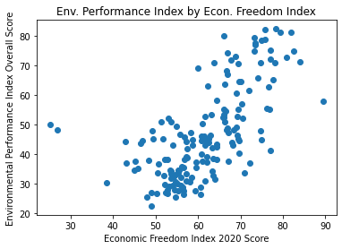

```python
fig, ax = plt.subplots()

# Do some labeling
ax.set_title('Env. Performance Index by Econ. Freedom Index')
ax.set_xlabel('Economic Freedom Index 2020 Score')
ax.set_ylabel('Environmental Performance Index Overall Score')

# Create the scatterplot
ax.scatter(epi_efi_2020['2020 Score'], epi_efi_2020['EPI.new'])
```

The scatterplot shows a general positive correlation with some notable outliers.

This intuition can be verified by plotting a regression line through the dataset. The linear regression line is the line that minimizes the residuals. A residual is the distance between a true datapoint and its predicted value (the y value on the regression line). In other words, a linear regression line is the line which, if used to predict the actual `y` value for a given `x` value, would be the least incorrect for all actual datapoints.

A linear regression line is technically a 1D polynomial function. If we think of it that way, the `NumPy` library has some useful functions for creating that line. Read more about `NumPy` at https://numpy.org/.

First, `NumPy` has the `polyfit` function which will perform linear regression and return the constant and coefficient that will define the line (the `b` and `m` in `mx + b`). Next, the `poly1d` function can take in those coefficients and return a function that takes in an `x` value and returns the predicted `y` value.

This line function can be plotted for all the possible `x` values to create the regression line.

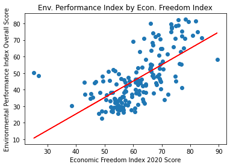

```python
# drop any rows that have a NaN in the '2020 Score' column, otherwise will be errors
epi_efi_2020 = epi_efi_2020.dropna(subset=['2020 Score'])

# we will reuse this function later
# it takes a dataframe, name of column for x and y values, and an Axis object to plot on
def plot_reg_line(df, x, y, ax):
    # create function to output values for line given coefficients
    _pf = np.polyfit(df[x], df[y], 1)
    _line = np.poly1d(_pf)
    # plot the regression line
    ax.plot(df[x], _line(df[x]), color='r')

# use the above function on the joined tables
plot_reg_line(epi_efi_2020, '2020 Score', 'EPI.new', ax)

# must have this here so that plot shows again
fig
```

The line verifies the intuition for a positive correlation––we can see it slopes upwards.

# Hypothesis Testing

However, the correlation may not be statistically significant. The way to determine if it is statistically significant is by calculating the p-values for its coefficients.

The p-value is a measure of how likely an outcome is assuming that a "null hypothesis" is true. In this case, the null hypothesis would be that there is no correlation between EFI and EPI.

We can use the `statsmodels` library to recalculate the ordinary least squares line (OLS). The object returned will have a method `pvalues` that will return a p-value for each coefficient. This OLS line will have the same coefficients as the line that we created using `NumPy`, but `NumPy` does not let us view the p-value as easily, so the `statsmodels` library must be used for this added feature. Read more about `statsmodels` at https://www.statsmodels.org/stable/index.html.

```python
# a function we will reuse
# takes in a dataframe, x and y column names
# prints out the p-values for the constant and coefficient
# of least-squares regression line
def print_p_values(df, xcol, ycol):
    # x column values must be reshaped so that each sample is an array of features (of size 1 in this case)
    X = sm.add_constant(df[xcol].values.reshape(-1,1))
    y = df[ycol].values
    est = sm.OLS(y, X)
    # fit regression line to OLS object
    fitted = est.fit()
    # access the p values and print them
    print(f'constant p-value: {fitted.pvalues[0]}')
    print(f'coef p-value: {fitted.pvalues[1]}')

# another reusable function that will print out the
# parameters, meaning the constant and coefficient of the
# fitted model
def print_params(df, xcol, ycol):
    X = sm.add_constant(df[xcol].values.reshape(-1,1))
    y = df[ycol].values
    est = sm.OLS(y, X)
    fitted = est.fit()
    print(f'constant: {fitted.params[0]}')
    print(f'coef: {fitted.params[1]}')

print_params(epi_efi_2020, '2020 Score', 'EPI.new')
print_p_values(epi_efi_2020, '2020 Score', 'EPI.new')
```

```
constant: -14.271539070528465
coef: 0.990246604299394
constant p-value: 0.011918340818167433
coef p-value: 1.554930802785755e-21
```

What does a p-value mean? It is the probability of seeing a result at least extreme as the one found, assuming the null hypothesis is true. To determine statistical significance, an `alpha` value is selected, for example .05. If the p-value is less than that `alpha` value (or `alpha / 2` in a 2-sided hypothesis test), we deem it too unlikely a result. In that case, we "reject the null hypothesis"

Read more about one versus two-tailed tests [here](https://stats.idre.ucla.edu/other/mult-pkg/faq/general/faq-what-are-the-differences-between-one-tailed-and-two-tailed-tests/#:~:text=A%20two%2Dtailed%20test%20will,p%2Dvalue%20less%20than%200.05.).

# More Exploratory Data Analysis

## Correlation Matrix Heatmap

This right data structure to represent all these correlations is, of course, a matrix. One axis will be EPI factors and the other axis will be the EFI indicators. Each cell will contain the correlation between those two elements, which is the slope of the linear regression line if those two elements were graphed on a 2D plane. That correlation can be positive or negative, just as the slope could be, of course.

This data structure can be visualized in the form of a heat map where the more positive a correlation the "warmer" the cell's color and the more negative the correlation the "cooler" the cell's color.

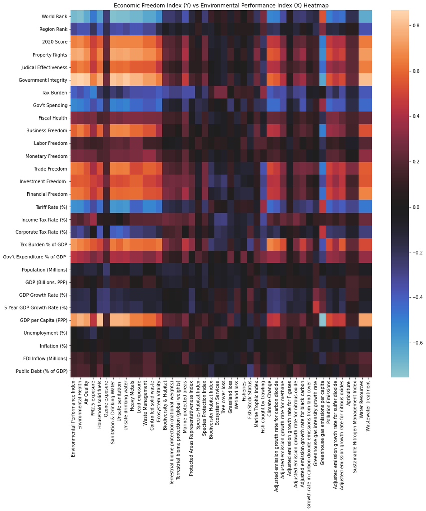

```python
# create a large figure to fit all of the labels
fix, ax = plt.subplots(figsize=(15,15))

ax.set_title('Economic Freedom Index (Y) vs Environmental Performance Index (X) Heatmap')

# isolate the names of the current-year score columns (i.e. H20.new and not H20.rank.new, H20.change)
epi_score_col_names = [ name for name in epi_2020.columns if "new" in name and "rnk" not in name ]

# isolate the column names in efi which have a float score value (omitting string data like 'Region')
efi_score_col_names = efi_2020.select_dtypes('float64').columns

# select those isolated efi and epi score columns from the joined table
reduced = epi_efi_2020[list(efi_score_col_names) + epi_score_col_names]

# run correlation
full_correlation = reduced.corr()

# reduce to a matrix of just (epi column names x efi row names)
mat = full_correlation[epi_score_col_names].loc[efi_score_col_names]

# replace the epi column abbreviations with their full names by looking them up in the indicators table
mat.columns = [ indicators[indicators['Abbreviation'] == abbr[0:3]].iloc[0]['Variable'] for abbr in mat.columns]

# plot the heatmap and make zero correlation black by setting center=0
sns.heatmap(mat, center=0)
```

This heatmap is extremely informative in breaking down the big picture trend and looking at the individual correlations that will better tell the whole story of what economic qualities of a country affect environmental performance.

There is lots of blue and lots of orange on the map which provides the intuition that the story is more complicated than the simple conclusion of more economic freedom being better for the environment across the board.

It should be noted the "more is better"/"less is worse" intuitions might be confusing for a few of the indicators. For example, the highest score on "Government Spending" indicates that the government is not spending any money. So if more government spending resulted in a higher score on some environmental indicator, that would be a **negative** correlation. This is important to keep in mind.

# More Exploratory Data Analysis and Communication of Insights Attained

## Interpreting the Heatmap

It will be informative to look at an example of high, no, and low correlations in depth. In other words, which elements that contribute to economic freedom correlate positively versus negatively with different elements of environmental performance?

### High Positive Correlation Areas

In the top left there is a bright orange area. This area is where "Property Rights", "Judicial Effectiveness", and "Government Integrity" overlap with environmental health indicators such as "Air Quality", "Unsafe Drinking Water", and "Lead Exposure".

This is a first major insight into why more economic freedom is contributing to higher environmental performance.

A good intuition here could be that

- higher government integrity helps positive government-run environmental health projects get completed
- higher judicial effectiveness ensures that entities that are damaging public health are held accountable
- property rights is harder to interperet, but it is possible better property rights ensures more accountability from individuals to improve public health

But maybe it is not quite that direct of a causation. For example, a hypothesis could be that "Property Rights", "Judicial Effectiveness", and "Government Integrity" simply correlate the most with "GDP per Capita". Because of this, countries with those 3 EFI indicators are the same countries who just have a lot a money and thus can afford to spend more on environmental public health measures.

To investigate this I want to confirm that "Property Rights", "Judicial Effectiveness", and "Government Integrity" correlate with increased wealth, so I plot all three of them with GDP per capita.

In the last spot I plot the GDP per Capita by 2020 Score to see if there is an overall positive correlation between a higher freedom score and richer countries.

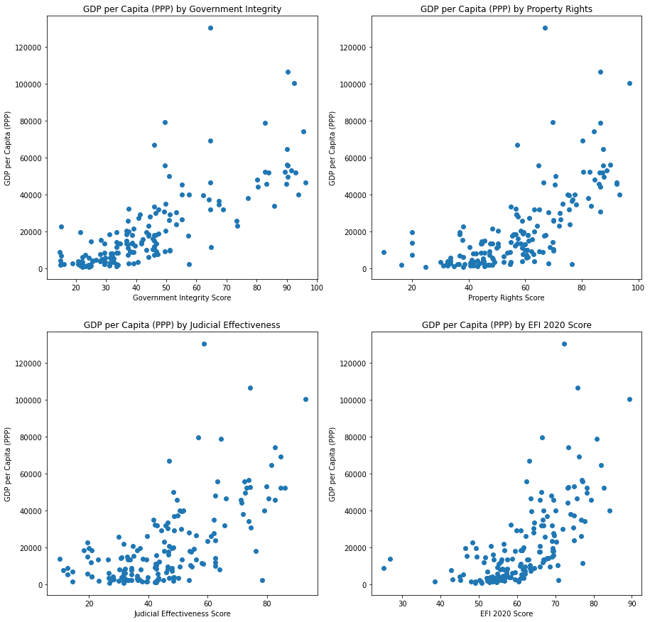

```python
# create a large figure of size 2x2
fig, ax = plt.subplots(2, 2, figsize=(15, 15))

# 2D array -> 1D array
ax = ax.reshape(-1)

# all y axis are GDP per cap, so plot all at once
for i in range(0,4):
    ax[i].set_ylabel('GDP per Capita (PPP)')

# top left
ax[0].set_title('GDP per Capita (PPP) by Government Integrity')
ax[0].set_xlabel('Government Integrity Score')
ax[0].scatter(epi_efi_2020['Government Integrity'], epi_efi_2020['GDP per Capita (PPP)'])

# top right
ax[1].set_title('GDP per Capita (PPP) by Property Rights')
ax[1].set_xlabel('Property Rights Score')
ax[1].scatter(epi_efi_2020['Property Rights'], epi_efi_2020['GDP per Capita (PPP)'])

# bottom left
ax[2].set_title('GDP per Capita (PPP) by Judicial Effectiveness')
ax[2].set_xlabel('Judicial Effectiveness Score')
ax[2].scatter(epi_efi_2020['Judical Effectiveness'], epi_efi_2020['GDP per Capita (PPP)'])

# bottom right
ax[3].set_title('GDP per Capita (PPP) by EFI 2020 Score')
ax[3].set_xlabel('EFI 2020 Score')
ax[3].scatter(epi_efi_2020['2020 Score'], epi_efi_2020['GDP per Capita (PPP)'])
```

Visually, I can see that there is a positive correlation for all of these plots. Therefore, "Property Rights", "Judicial Effectiveness", and "Government Integrity" could simply be great indicators of a country's wealth.

In fact, the EPI website concludes from their own analysis that results from good policies can be attributed to wealth, especially in terms of environmental health.

# More Hypothesis Testing

It would be useful to see just how tightly correlated economic freedom is with GDP per capita (a good measure of a country's overall wealth), as seen in the last plot above.

```python
print_p_values(epi_efi_2020, '2020 Score', 'GDP per Capita (PPP)')
```

```
constant p-value: 9.014677720561101e-14
coef p-value: 3.1605852782000747e-21
```

The coefficient p-value is extremely low, which means we can say with a lot of certainty that there is a strong correlation.

## Is more economic freedom always better?

So, overall, being a wealthier country is correlated with a higher EPI score. This begs the question––do economically freer countries always do better in terms of Environmental Performance.

Looking at the "2020 Score" row in the heatmap, the first column with a much lower positive correlation (very dark orange) is the Biodiversity and Habitat issue category. Plot it like previous scatterplots:

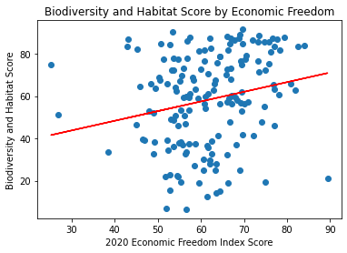

```python
fig, ax = plt.subplots()
ax.set_xlabel('2020 Economic Freedom Index Score')
ax.set_ylabel('Biodiversity and Habitat Score')
ax.set_title('Biodiversity and Habitat Score by Economic Freedom')
ax.scatter(epi_efi_2020['2020 Score'], epi_efi_2020['BDH.new'])

plot_reg_line(epi_efi_2020, '2020 Score', 'BDH.new', ax)
```

The correlation here is much less apparent. However, it can still be shown to be statistically significant by calculating the p-values.

```python
print_params(epi_efi_2020.dropna(subset=['BDH.new']), '2020 Score', 'BDH.new')
print_p_values(epi_efi_2020.dropna(subset=['BDH.new']), '2020 Score', 'BDH.new')
```

```
constant: 30.0812362365264
coef: 0.4567270973183885
constant p-value: 0.0038827038236728035
coef p-value: 0.006033080228088055
```

While still significant, the weaker correlation does suggest that economic freedom does not have as big of an impact on protecting biodiversity when compared with promoting environmental health. Let's do some more hypothesis testing on the correlation between economic freedom and environmental health to better back up this conclusion.

To illustrate this, plot environmental health by EFI Score below. It's clear that the slope is much steeper and residuals are much smaller.

Run the coefficient and p-value calculations as well to verify these visual observiations statistically. The coefficient p-value is extremely low.

```
constant: -52.22313580507338
coef: 1.5893881507883942
constant p-value: 3.854048345253563e-09
coef p-value: 8.294177174032485e-24
```

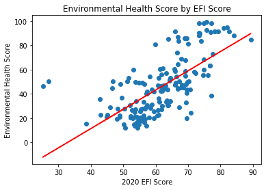

```python
fig, ax = plt.subplots()
ax.set_xlabel('2020 EFI Score')
ax.set_ylabel('Environmental Health Score')
ax.set_title('Environmental Health Score by EFI Score')
ax.scatter(epi_efi_2020['2020 Score'], epi_efi_2020['HLT.new'])

plot_reg_line(epi_efi_2020, '2020 Score', 'HLT.new', ax)
print_params(epi_efi_2020.dropna(subset=['HLT.new']), '2020 Score', 'HLT.new')
print_p_values(epi_efi_2020.dropna(subset=['HLT.new']), '2020 Score', 'HLT.new')
```

### Ecosystem Services

Looking at the heatmap again, the Ecosystem Services column shows no correlation (black) with the Economic Freedom Index Score. Plotting this correlation will give us a better intuition into why:

```
constant: 51.6575728229709
coef: -0.16383414725114176
constant p-value: 1.1106375058695307e-05
coef p-value: 0.3685006458267217
```

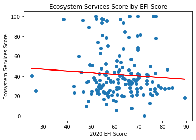

```python
_df = epi_efi_2020.dropna(subset=['ECS.new'])
fig, ax = plt.subplots()
ax.set_xlabel('2020 EFI Score')
ax.set_ylabel('Ecosystem Services Score')
ax.set_title('Ecosystem Services Score by EFI Score')
ax.scatter(_df['2020 Score'], _df['ECS.new'])

plot_reg_line(_df, '2020 Score', 'ECS.new', ax)
print_params(_df.dropna(subset=['ECS.new']), '2020 Score', 'ECS.new')
print_p_values(_df.dropna(subset=['ECS.new']), '2020 Score', 'ECS.new')
```

The regression line slopes slightly down, however the coefficient p-value tells us that this correlation is not statistically significant compared to no correlation.

This can be seen intuitively because countries with both high and low Economic Freedom Scores score highly on Ecosystem Services. Similarly countries with both high and low Economic Freedom Scores score poorly on Ecosystem Services.

Overall, most countries score pretty poorly regardless of Economic Freedom.

### Greenhouse Gas Emissions

So to summarize so far,

- Environmental Health has strong positive correlation with EFI
- Biodiversity & Habitat has weak positive correlation with EFI
- Ecosystem Services has no correlation with EFI

So what about a negative correlation? Where are economically freer/richer countries doing worse?

Again looking at the heatmap row for 2020 EFI Score, there is one bright blue square––Greenhouse Gas Emissions per Capita.

Let's plot it:

```
Left Plot
constant: 135.5662626187937
coef: -1.3817824711051858
constant p-value: 1.118801011789504e-22
coef p-value: 1.1771107425571279e-11

Right Plot
constant: 70.80491108146339
coef: -0.0009687361455094539
constant p-value: 1.054234977510806e-77
coef p-value: 1.8586423624521183e-31
```

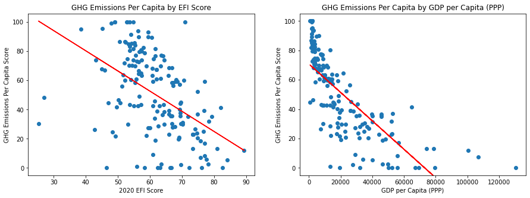

```python
# copy df over for cleanliness
_df = epi_efi_2020.copy()

# create two side by side plots inside a big figure
fig, ax = plt.subplots(1, 2, figsize=(15,5))

# left plot
ax[0].set_xlabel('2020 EFI Score')
ax[0].set_ylabel('GHG Emissions Per Capita Score')
ax[0].set_title('GHG Emissions Per Capita by EFI Score')
ax[0].scatter(_df['2020 Score'], _df['GHP.new'])

# run regression and print statistics
plot_reg_line(_df, '2020 Score', 'GHP.new', ax[0])
print('Left Plot')
print_params(_df.dropna(subset=['GHP.new']), '2020 Score', 'GHP.new')
print_p_values(_df.dropna(subset=['GHP.new']), '2020 Score', 'GHP.new')

# right plot
ax[1].set_xlabel('GDP per Capita (PPP)')
ax[1].set_ylabel('GHG Emissions Per Capita Score')
ax[1].set_title('GHG Emissions Per Capita by GDP per Capita (PPP)')
ax[1].scatter(_df['GDP per Capita (PPP)'], _df['GHP.new'])
# set the y limit at -5, otherwise the plot will have too much space in the negatives
# on the y axis due to the regression line
ax[1].set_ylim(-5)

# run regression and print statistics
print('\nRight Plot')
plot_reg_line(_df, 'GDP per Capita (PPP)', 'GHP.new', ax[1])
print_params(_df, 'GDP per Capita (PPP)', 'GHP.new')
print_p_values(_df, 'GDP per Capita (PPP)', 'GHP.new')
```

Both have strong negative correlations. The second plot has an even stronger negative correlation, which suggests that GDP affects GHG emissions even more negatively than purely economic freedom.

# Machine Learning

The line in the second plot seems to not fit very well however. The data doesn't seem linear in nature just by looking at it.

Let's try a machine learning technique to see if we can better predict the GHG score based on GDP per capita compared to a purely linear model. Admittedly, this example is a bit contrived, but it is a good simple demonstration of the power of a non-linear model.

A K-Nearest-Neighbor regression model is a good choice to compare to ordinary-least-squares linear regression. Read about it at https://en.wikipedia.org/wiki/K-nearest_neighbors_algorithm. Other possibilites could be a decision tree or a non-linear SVM. Since there is only one "feature" in this model, the simplicity of KNN makes it favorable. If there were many more features the decision tree model could be an interesting choice, for example.

In order to properly compare the KNN and linear regression line, first find the optimal `n_neighbors` hyperparameter for the KNN model. This is the most important hyperparameter––it determines how many points the model looks at to make a prediction.

First, set up the `X` and `y` values to use for training.

```python
# copy for cleanliness
_df = epi_efi_2020.copy()

# Must be reshaped so that each sample is an array (of size 1 in this case)
X = _df['GDP per Capita (PPP)'].values.reshape(-1,1)
y = _df['GHP.new'].values
```

The `sklearn` library provides a `GridSearchCV` functionality that runs a grid search over all possible hyperparameters and finds the best one based on the best cross-validation error.

```python
# specify hyperparams
dt_param_grid = { 'n_neighbors': range(1,100) }
# create the grid search and run fit
# cv of 10 means the grid search will use 10-Fold cross-validation
dt_search = model_selection.GridSearchCV(estimator = KNeighborsRegressor(), \
                                         param_grid=dt_param_grid, cv=10).fit(X,y)
```

View the best selected hyperparameters:

```python
dt_search.best_params_
```

```
{'n_neighbors': 19}
```

Now that we have an optimal `n_neighbors` value of 19, we can compare how good the KNN regression model is compared to regular linear regression.

`sklearn` has a `cross_val_score` functionality that will do n-fold cross-validation, which can be averaged to provide a more accurate estimate of model performance. This is compared to choosing only one cross-validation train/test split and using that cross-validation error to evaluate the model. If you only choose one cross-validation split, you may get a biased estimate for the cross-validaton error that would be balanced out with more splits.

Negative mean squared error is used below as the scoring method. It is made negative so that a higher value means the model performed better (maximization vs minimization).

```python
print('Linear Regression Results: ')
print(model_selection.cross_val_score(LinearRegression(), X, y, cv=10, scoring='neg_mean_squared_error').mean())
print('KNN Results: ')
print(model_selection.cross_val_score(KNeighborsRegressor(n_neighbors=19), X, y, cv=10, scoring='neg_mean_squared_error').mean())
```

```
Linear Regression Results:
-377.8604435371111
KNN Results:
-216.8037239693661
```

The results show that the KNN Regressor has a better error value, which means it is the better performing model. Therefore, this nonlinear model is the better choice compared to using linear regression.

To visually see why, plot the KNN line over the scatterplot:

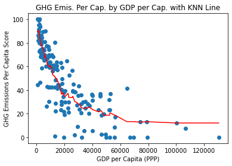

```python
# get the fitted model
fitted = KNeighborsRegressor(n_neighbors=19).fit(X,y)

fig, ax = plt.subplots()

# X needs to be sorted so that the line will come out correctly.
# It needs to be converted back into a Numpy array afterwards
# so that reshape will work
_X = np.array(sorted(X.squeeze()))

# predict the y value for each X value
_y = fitted.predict(_X.reshape(-1,1))

# labels
ax.set_xlabel('GDP per Capita (PPP)')
ax.set_ylabel('GHG Emissions Per Capita Score')
ax.set_title('GHG Emis. Per Cap. by GDP per Cap. with KNN Line')

# plot the line
ax.plot(_X, _y, color='r')
# re plot the real points
ax.scatter(X, y)
```

The flattening curve means that most of the worsening GHG emissions happen when countries begin becoming wealthier. Wealthy countries can become even wealthier with less and less loss to their emissions score. This could signify that they are decoupling their economic growth from emissions.

# Insights

So what insights has this in-depth analysis provided?

By going through the data science pipeline, there is now a much more complex story about how economic freedom relates to a country's environmental stewardship. Economically free countries are wealthier, and that wealth is correlated with high environmental health ratings (clean air, water, sanitation, etc). While this is something to celebrate, this is only one aspect to environmental progress.

Economic freedom and wealth does not correlate as strongly with protecting biodiversity and conservation, which could be troubling, since it takes wealth to be able to afford to care about biodiversity and conservation rather than simply trying to survive economically. Therefore, we should investigate why wealth is not correlating as strongly as it should with better biodiversity and conservation scores.

Even worse, economic freedom correlates negatively with GHG emissions. The more free and wealthy a country is economically, the worse it is when it comes to greenhouse gas emissions. It is hard (or even undesireable) to put a value judgement on whether environmental health, biodiversity, or greenhouse gas emissions are more dangerous. Certainly, environmental health is an extremely immediate issue that saves lives every dat. But the devastation that could be caused by massive biodiversity loss or a rapidly changing climate is hard to predict because it is hard to model the complex effects of such changes. Are wealthy countries being held accountable enough considering the risk of such damage?

In summary, high-level correlation between economic freedom and environmental performance through the Yale and Heritage Foundaction Indices can be said to capture the more immediate, easier to measure aspects of environmental performance. However, it does not vindicate economically freer countries in any way from their poor environmental performance in the hard-to-quantify arenas of conservation and climate change impacts.

# Future Work and Further Considerations

A *major* caveat in this data is that it does not capture "transboundary" environmental impact. This means it only evaluates a country's performance internally and would not include, for example, the impacts of a country via the impacts of imported products in the places they are imported from. This could potentially drastically change some of the data and conclusions if incorporated properly.

# Sources

[1] https://towardsdatascience.com/are-free-markets-wrecking-the-environment-f88fbdc88bf1